# Reproducible Research: Peer Assessment 1

## Loading and preprocessing the data

This code will load the input data

```r
data<-read.csv("D:\\CourseraCourses\\ReproducibleResearch\\activity.csv")
str(data)
```

```
## 'data.frame':    17568 obs. of  3 variables:
##  $ steps   : int  NA NA NA NA NA NA NA NA NA NA ...
##  $ date    : Factor w/ 61 levels "2012-10-01","2012-10-02",..: 1 1 1 1 1 1 1 1 1 1 ...
##  $ interval: int  0 5 10 15 20 25 30 35 40 45 ...
```

## What is mean total number of steps taken per day?

This code does:

Calculate the total number of steps taken per day

Make a histogram of the total number of steps taken each day

Calculate and report the mean and median of the total number of steps taken per day

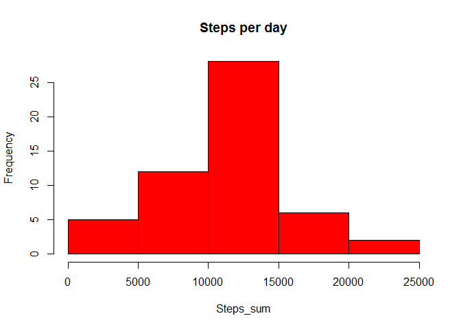

```r
manipulated<-aggregate(steps ~ date, data, sum)
hist(manipulated$steps, col="red", xlab="Steps_sum", main="Steps per day")
```

```r
mean_by_date<-mean(manipulated$steps)
median_by_date<-median(manipulated$steps)
mean_by_date
```

```
## [1] 10766.19
```

```r
median_by_date
```

```
## [1] 10765
```

## What is the average daily activity pattern?

This code does:

Make a time series plot (i.e. type = “l”) of the 5-minute interval (x-axis) and the average number of steps taken, averaged across all days (y-axis)

Tells which 5-minute interval, on average across all the days in the dataset, contains the maximum number of steps

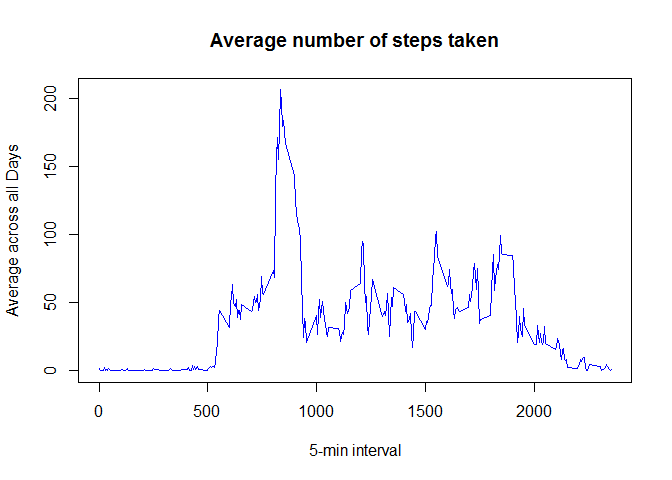

```r
manipulated_interval<-aggregate(steps ~ interval, data, mean)
plot(steps~interval, manipulated_interval, type = "l", xlab = "5-min interval", ylab = "Average across all Days", main = "Average number of steps taken", col = "blue")
```

```r
manipulated_interval[which.max(manipulated_interval$steps), 1]
```

```
## [1] 835
```

## Imputing missing values

This code does:

Fills in all of the missing values in the dataset, using the mean for that 5-minute interval

Creates a new dataset that is equal to the original dataset but with the missing data filled in.

Make a histogram of the total number of steps taken each day

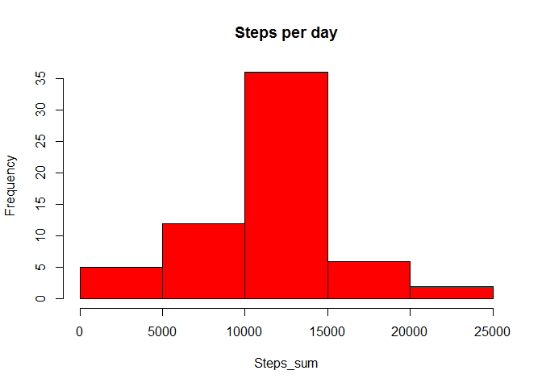

```r
missing_indexes<-which(is.na(data$steps))
number_of_missing_values<-length(missing_indexes)
data_new<-data
for(i in missing_indexes){
  data_new[i,1]<-as.integer(manipulated_interval[which(data[i,3]==manipulated_interval$interval),]$steps)
}
manipulated_new<-aggregate(steps ~ date, data_new, sum)
hist(manipulated_new$steps, col="red", xlab="Steps_sum", main="Steps per day")
```

```r
mean_by_date_new<-mean(manipulated_new$steps)
median_by_date_new<-median(manipulated_new$steps)
mean_by_date - mean_by_date_new
```

```
## [1] 16.41819
```

```r
median_by_date - median_by_date_new
```

```
## [1] 124
```

## Are there differences in activity patterns between weekdays and weekends?

This code does:

Create a new factor variable in the dataset with two levels – “weekday” and “weekend” indicating whether a given date is a weekday or weekend day.

Make a panel plot containing a time series plot (i.e. type = “l”) of the 5-minute interval (x-axis) and the average number of steps taken, averaged across all weekday days or weekend days (y-axis).

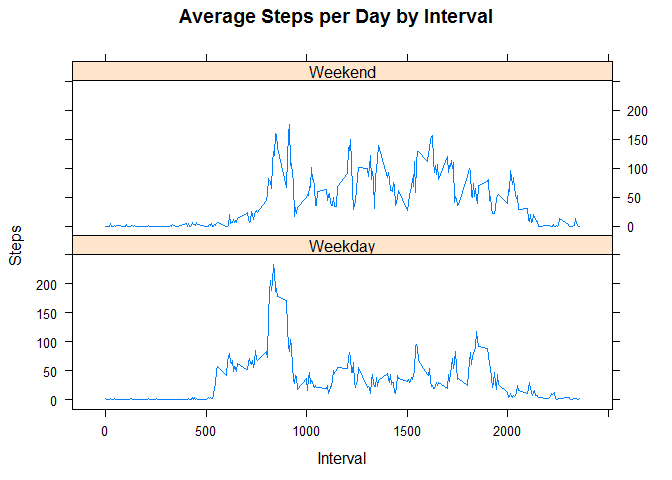

```r
weekdays <- c("Monday", "Tuesday", "Wednesday", "Thursday", "Friday")
data$day = as.factor(ifelse(is.element(weekdays(as.Date(data$date)),weekdays), "Weekday", "Weekend"))
manipulated_interval_day <- aggregate(steps ~ interval + day, data, mean)
library(lattice)
xyplot(manipulated_interval_day$steps ~ manipulated_interval_day$interval|manipulated_interval_day$day, main="Average Steps per Day by Interval",xlab="Interval", ylab="Steps",layout=c(1,2), type="l")
```